# Publications

2020-05-30

## **Recent work**:

**NAFTA-USMCA and wages in Mexico**

**(with Santiago Levy, 2022)**

[figure not shown]

In this note we assess the impact of NAFTA on wages in Mexico by focusing on some features of Mexico’s labor market. We find that:

- Despite NAFTA, average wages in Mexico did not increase from their pre-NAFTA levels, although in its absence they would have been marginally lower.
- So long as Mexico’s current domestic regulations remain — particularly those pertaining to labor and social insurance — it is unlikely that the U.S.-Mexico-Canada Agreement (USMCA), the trade pact that superseded NAFTA in 2019, will lead to higher average wages.
- If the USMCA increases labor costs significantly in the USMCA-related segment of the economy, aggregate productivity in Mexico may suffer.

[**Read the full note**](https://www.brookings.edu/essay/usmca-forward-building-a-more-competitive-inclusive-and-sustainable-north-american-economy-labor/)

## **Technical Notes**:

**The Longitudinal Linkage of Mexico’s Economic Census 1999-2014**

**(with Matias Busso and Santiago Levy, 2018)**

[figure not shown]

This technical note describes the methodology to construct a longitudinal dataset using the Economic Censuses of Mexico from 1999 to 2014.

- The procedure is based on an algorithm that links establishments with identical or significantly similar location, legal entity and industry.
- Since a set of longitudinal identifiers is already available for the 2009 and 2014 Economic Censuses, it is used to validate our results, obtaining 90 percent accuracy.
- The note links 1.44 million establishments for the period 1999-2004, 1.52 million for 2004-2009 and 2.15 million for 2009-2014.

[**Read the full article**](https://publications.iadb.org/en/longitudinal-linkage-mexicos-economic-census-1999-2014)

See also:

[Busso, M., Fentanes, O., & Levy Algazi, S. (2019). Vinculación longitudinal de los Censos Económicos 1994-2014 de México. *REALIDAD, DATOS Y ESPACIO*. Vol. 10, Núm. 2, mayo-agosto, 2019](https://rde.inegi.org.mx/index.php/2019/08/20/vinculacion-longitudinal-de-los-censos-economicos-1994-2014-de-mexico/)

## **Working Papers**:

**The Heterogeneous Impacts of Import Competition on Mexican Manufacturing Plants**

**(with Juan Blyde, 2019)**

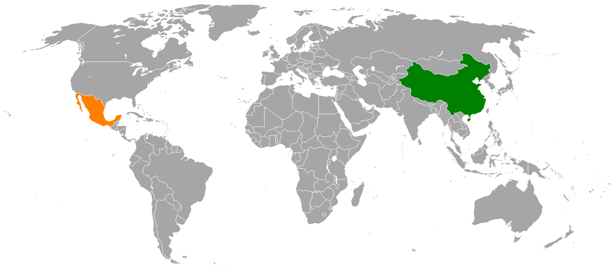

In this paper, we study the impact of import competition from China on Mexican firms between 2003 and 2013 by exploiting variation in import penetration across industries. We find that:

- The trade shock induced a decline in employment, sales, exports, and productivity.
- Smaller and less efficient plants experienced the largest adjustments, while the most efficient plants exhibited relatively minor effects.

[**Read the full article**](https://publications.iadb.org/en/heterogeneous-impacts-import-competition-mexican-manufacturing-plants)

## **Memoirs**:

[Fentanes, O. (2014). Esquemas de inversión privada en la nueva arquitectura del sector petrolero en México.](http://repositorio-digital.cide.edu/handle/11651/2503)

## **As research assistant**:

[Busso, M., Levy, S., Torres, J. (2019). Establishment dynamics and the persistence of resource misallocation in Mexico: An analysis of longitudinal data for 1998-2013](http://jesicatorres.com/wp-content/uploads/2020/03/PaperDynamics-v1.pdf)

[Levy, S. (2018). *Under-rewarded efforts: The elusive quest for prosperity in Mexico*. Inter-American Development Bank](https://publications.iadb.org/publications/english/document/Under-Rewarded_Efforts_The_Elusive_Quest_for_Prosperity_in_Mexico.pdf)

[Garcia-Marin, A., & Voigtländer, N. (2019). Exporting and plant-level efficiency gains: It’s in the measure. *Journal of Political Economy*, 127(4), 1777-1825.](https://www.journals.uchicago.edu/doi/abs/10.1086/701607)

[figure not shown]